# Actividad 3 - Regresion Simple y Multiple con datos intradia (LSEG)

2026-10-19

## Librerias

```r
library(readxl)
library(quantmod)
library(car)
library(lmtest)
```

## Datos

Los precios intradia se bajaron de LSEG Workspace (Price History) y se juntaron en el archivo “Datos intradia LSEG.xlsx”, con una hoja por intervalo. La hora esta en hora de Nueva York y solo se dejo el horario normal de mercado (9:30 a 16:00).

- 1 minuto: 9 de octubre de 2026.
- 5 minutos: 8 y 9 de octubre de 2026.
- 30 minutos: 5 al 9 de octubre de 2026.

Para 1 y 5 minutos se usaron 1 y 2 dias, como piden las instrucciones. Para 30 minutos se uso la semana completa porque con 1 o 2 dias solo habria 13 a 26 rendimientos, muy pocos para estimar un modelo con 3 variables independientes.

Esta funcion lee una hoja, se queda con los minutos donde todas las acciones del modelo tienen precio y calcula el rendimiento de cada intervalo. No se usa el rendimiento de la noche (del cierre de un dia a la apertura del siguiente), solo rendimientos dentro del mismo dia.

```r
leer_rend <- function(hoja, cols) {
  datos <- as.data.frame(read_excel("Datos intradia LSEG.xlsx", sheet = hoja))
  datos <- na.omit(datos[, c("fecha_hora_NY", cols)])
  n <- nrow(datos)
  rend <- datos[-1, cols] / datos[-n, cols] - 1
  mismo_dia <- as.Date(datos$fecha_hora_NY[-1]) == as.Date(datos$fecha_hora_NY[-n])
  rend <- as.data.frame(rend)[mismo_dia, , drop = FALSE]
  colnames(rend) <- cols
  rend
}
```

```r
r1 <- leer_rend("1min", c("nvda", "msft", "jpm", "spy", "bac", "tlt"))
r5 <- leer_rend("5min", c("nvda", "msft", "jpm", "spy", "bac", "tlt"))
r30 <- leer_rend("30min", c("nvda", "msft", "jpm", "spy", "bac", "tlt"))
```

## Modelos originales (semanales, Tareas 1 y 2)

Para comparar, se vuelven a calcular los modelos originales con rendimientos semanales de enero de 2023 al 2 de octubre de 2026.

```r
getSymbols(c("NVDA", "MSFT", "JPM", "SPY", "BAC", "TLT"), from = "2023-01-01", to = "2026-10-03")
```

```
## [1] "NVDA" "MSFT" "JPM"  "SPY"  "BAC"  "TLT"
```

```r
semanal <- na.omit(merge(weeklyReturn(NVDA$NVDA.Close), weeklyReturn(MSFT$MSFT.Close),
                         weeklyReturn(JPM$JPM.Close), weeklyReturn(SPY$SPY.Close),
                         weeklyReturn(BAC$BAC.Close), weeklyReturn(TLT$TLT.Close)))
colnames(semanal) <- c("nvda", "msft", "jpm", "spy", "bac", "tlt")
semanal <- as.data.frame(semanal)
```

```r
modeloA_sem <- lm(nvda ~ msft, data = semanal)
summary(modeloA_sem)
```

```
##
## Call:
## lm(formula = nvda ~ msft, data = semanal)
##
## Residuals:
##       Min        1Q    Median        3Q       Max
## -0.213251 -0.034948 -0.001363  0.036160  0.197143
##
## Coefficients:
##             Estimate Std. Error t value Pr(>|t|)
## (Intercept) 0.012592   0.003933   3.201   0.0016 **
## msft        0.787198   0.104336   7.545 1.71e-12 ***
## ---
## Signif. codes:  0 '***' 0.001 '**' 0.01 '*' 0.05 '.' 0.1 ' ' 1
##
## Residual standard error: 0.05465 on 194 degrees of freedom
## Multiple R-squared:  0.2269, Adjusted R-squared:  0.2229
## F-statistic: 56.92 on 1 and 194 DF,  p-value: 1.712e-12
```

```r
modeloB_sem <- lm(jpm ~ spy + bac + tlt, data = semanal)
summary(modeloB_sem)
```

```
##
## Call:
## lm(formula = jpm ~ spy + bac + tlt, data = semanal)
##
## Residuals:
##       Min        1Q    Median        3Q       Max
## -0.052289 -0.008135  0.000861  0.010012  0.058772
##
## Coefficients:
##              Estimate Std. Error t value Pr(>|t|)
## (Intercept)  0.001589   0.001220   1.302 0.194392
## spy          0.362048   0.077882   4.649  6.2e-06 ***
## bac          0.594365   0.039341  15.108  < 2e-16 ***
## tlt         -0.240012   0.065840  -3.645 0.000344 ***
## ---
## Signif. codes:  0 '***' 0.001 '**' 0.01 '*' 0.05 '.' 0.1 ' ' 1
##
## Residual standard error: 0.01667 on 192 degrees of freedom
## Multiple R-squared:  0.7339, Adjusted R-squared:  0.7297
## F-statistic: 176.5 on 3 and 192 DF,  p-value: < 2.2e-16
```

## Modelo A - Regresion simple: NVDA vs MSFT (Tarea 1)

### 1 minuto

```r
modeloA_1 <- lm(nvda ~ msft, data = r1)
summary(modeloA_1)
```

```
##
## Call:
## lm(formula = nvda ~ msft, data = r1)
##
## Residuals:
##        Min         1Q     Median         3Q        Max
## -2.418e-03 -2.621e-04  1.975e-05  2.877e-04  2.730e-03
##
## Coefficients:
##               Estimate Std. Error t value Pr(>|t|)
## (Intercept) -3.783e-05  2.902e-05  -1.304  0.19319
## msft         1.444e-01  4.336e-02   3.331  0.00095 ***
## ---
## Signif. codes:  0 '***' 0.001 '**' 0.01 '*' 0.05 '.' 0.1 ' ' 1
##
## Residual standard error: 0.0005682 on 382 degrees of freedom
## Multiple R-squared:  0.02823,    Adjusted R-squared:  0.02568
## F-statistic:  11.1 on 1 and 382 DF,  p-value: 0.0009498
```

```r
confint(modeloA_1)
```

```
##                     2.5 %       97.5 %
## (Intercept) -9.488066e-05 1.922988e-05
## msft         5.918029e-02 2.296994e-01
```

```r
bptest(modeloA_1)
```

```
##
##  studentized Breusch-Pagan test
##
## data:  modeloA_1
## BP = 2.6941, df = 1, p-value = 0.1007
```

```r
dwtest(modeloA_1)
```

```
##
##  Durbin-Watson test
##
## data:  modeloA_1
## DW = 1.9711, p-value = 0.3892
## alternative hypothesis: true autocorrelation is greater than 0
```

### 5 minutos

```r
modeloA_5 <- lm(nvda ~ msft, data = r5)
summary(modeloA_5)
```

```
##
## Call:
## lm(formula = nvda ~ msft, data = r5)
##
## Residuals:
##        Min         1Q     Median         3Q        Max
## -0.0075105 -0.0006473  0.0000683  0.0006160  0.0042429
##
## Coefficients:
##               Estimate Std. Error t value Pr(>|t|)
## (Intercept) -0.0001680  0.0001096  -1.533   0.1274
## msft         0.1789496  0.0747518   2.394   0.0179 *
## ---
## Signif. codes:  0 '***' 0.001 '**' 0.01 '*' 0.05 '.' 0.1 ' ' 1
##
## Residual standard error: 0.001358 on 152 degrees of freedom
## Multiple R-squared:  0.03633,    Adjusted R-squared:  0.02999
## F-statistic: 5.731 on 1 and 152 DF,  p-value: 0.01789
```

```r
confint(modeloA_5)
```

```
##                     2.5 %       97.5 %
## (Intercept) -0.0003844822 4.851593e-05
## msft         0.0312628606 3.266363e-01
```

```r
bptest(modeloA_5)
```

```
##
##  studentized Breusch-Pagan test
##
## data:  modeloA_5
## BP = 0.6557, df = 1, p-value = 0.4181
```

```r
dwtest(modeloA_5)
```

```
##
##  Durbin-Watson test
##
## data:  modeloA_5
## DW = 1.8431, p-value = 0.1619
## alternative hypothesis: true autocorrelation is greater than 0
```

### 30 minutos

```r
modeloA_30 <- lm(nvda ~ msft, data = r30)
summary(modeloA_30)
```

```
##
## Call:
## lm(formula = nvda ~ msft, data = r30)
##
## Residuals:
##        Min         1Q     Median         3Q        Max
## -0.0083718 -0.0017937  0.0001202  0.0017236  0.0148880
##
## Coefficients:
##               Estimate Std. Error t value Pr(>|t|)
## (Intercept) -0.0004407  0.0004259  -1.035   0.3051
## msft         0.4059211  0.1550030   2.619   0.0112 *
## ---
## Signif. codes:  0 '***' 0.001 '**' 0.01 '*' 0.05 '.' 0.1 ' ' 1
##
## Residual standard error: 0.003288 on 58 degrees of freedom
## Multiple R-squared:  0.1057, Adjusted R-squared:  0.09032
## F-statistic: 6.858 on 1 and 58 DF,  p-value: 0.01124
```

```r
confint(modeloA_30)
```

```
##                    2.5 %       97.5 %
## (Intercept) -0.001293271 0.0004118349
## msft         0.095648931 0.7161931919
```

```r
bptest(modeloA_30)
```

```
##
##  studentized Breusch-Pagan test
##
## data:  modeloA_30
## BP = 7.5214, df = 1, p-value = 0.006097
```

```r
dwtest(modeloA_30)
```

```
##
##  Durbin-Watson test
##
## data:  modeloA_30
## DW = 1.9281, p-value = 0.3816
## alternative hypothesis: true autocorrelation is greater than 0
```

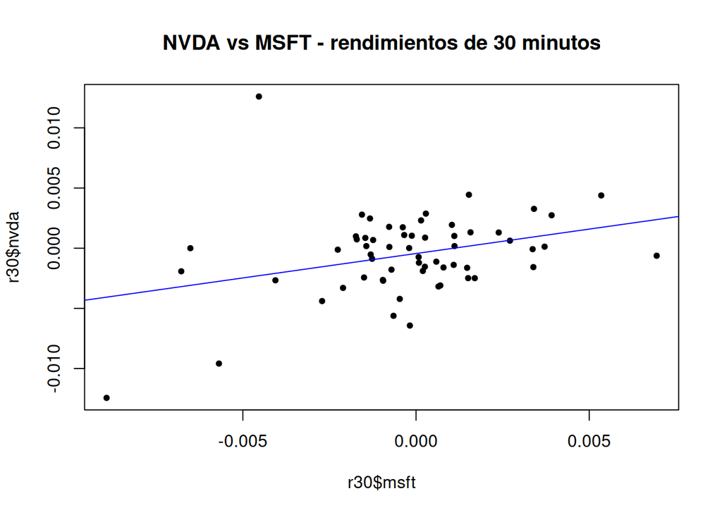

```r
plot(r30$msft, r30$nvda, pch = 20, main = "NVDA vs MSFT - rendimientos de 30 minutos")
abline(modeloA_30, col = "blue")
```

## Comentarios - Modelo A

A 1 minuto (384 rendimientos), si MSFT sube 1%, NVDA sube en promedio 0.14% (p < 0.001), pero el modelo solo explica el 3% de la variacion de NVDA (R2 = 0.028).

A 5 minutos (154 rendimientos) la beta es de 0.18 (p = 0.018) y el modelo explica el 4% (R2 = 0.036).

A 30 minutos (60 rendimientos) la beta sube a 0.41 (p = 0.011) y el modelo explica el 11% (R2 = 0.106).

En el modelo original semanal la beta es de 0.79 (p < 0.001) y explica el 23% (R2 = 0.227).

La relacion existe en todos los intervalos, pero entre mas largo el intervalo, mas grande la beta y el R2. Esto se conoce como efecto Epps: en intervalos muy cortos cada accion reacciona a la informacion con segundos o minutos de diferencia, asi que todavia no se mueven juntas; con intervalos mas largos la relacion aparece completa.

Supuestos:

- Heteroscedasticidad: Breusch-Pagan no la rechaza a 1 minuto (p = 0.10) ni a 5 minutos (p = 0.42), pero si a 30 minutos (p = 0.006): a 30 minutos la variacion de los errores cambia entre momentos del dia (mas al abrir y al cerrar).
- Autocorrelacion: el Durbin-Watson queda cerca de 2 en los tres intervalos (1.97, 1.84 y 1.93) y la prueba no rechaza la hipotesis de no autocorrelacion (p = 0.39, 0.16 y 0.38).

## Modelo B - Regresion multiple: JPM vs SPY + BAC + TLT (Tarea 2)

### 1 minuto

```r
modeloB_1 <- lm(jpm ~ spy + bac + tlt, data = r1)
summary(modeloB_1)
```

```
##
## Call:
## lm(formula = jpm ~ spy + bac + tlt, data = r1)
##
## Residuals:
##        Min         1Q     Median         3Q        Max
## -1.386e-03 -1.390e-04 -8.850e-06  1.507e-04  1.673e-03
##
## Coefficients:
##               Estimate Std. Error t value Pr(>|t|)
## (Intercept) -9.791e-06  1.441e-05  -0.679    0.497
## spy          1.430e-01  9.616e-02   1.487    0.138
## bac          6.244e-01  2.945e-02  21.200   <2e-16 ***
## tlt         -3.166e-02  6.447e-02  -0.491    0.624
## ---
## Signif. codes:  0 '***' 0.001 '**' 0.01 '*' 0.05 '.' 0.1 ' ' 1
##
## Residual standard error: 0.0002815 on 380 degrees of freedom
## Multiple R-squared:  0.5586, Adjusted R-squared:  0.5552
## F-statistic: 160.3 on 3 and 380 DF,  p-value: < 2.2e-16
```

```r
confint(modeloB_1)
```

```
##                     2.5 %       97.5 %
## (Intercept) -3.813101e-05 1.854823e-05
## spy         -4.611555e-02 3.320174e-01
## bac          5.664914e-01 6.823115e-01
## tlt         -1.584210e-01 9.509187e-02
```

```r
vif(modeloB_1)
```

```
##      spy      bac      tlt
## 1.153960 1.040469 1.122421
```

```r
bptest(modeloB_1)
```

```
##
##  studentized Breusch-Pagan test
##
## data:  modeloB_1
## BP = 7.1664, df = 3, p-value = 0.06678
```

```r
dwtest(modeloB_1)
```

```
##
##  Durbin-Watson test
##
## data:  modeloB_1
## DW = 2.3582, p-value = 0.9998
## alternative hypothesis: true autocorrelation is greater than 0
```

### 5 minutos

```r
modeloB_5 <- lm(jpm ~ spy + bac + tlt, data = r5)
summary(modeloB_5)
```

```
##
## Call:
## lm(formula = jpm ~ spy + bac + tlt, data = r5)
##
## Residuals:
##        Min         1Q     Median         3Q        Max
## -1.872e-03 -3.862e-04  2.909e-05  3.858e-04  2.865e-03
##
## Coefficients:
##               Estimate Std. Error t value Pr(>|t|)
## (Intercept)  1.594e-05  5.611e-05   0.284    0.777
## spy          1.252e-01  1.276e-01   0.982    0.328
## bac          6.031e-01  4.947e-02  12.191   <2e-16 ***
## tlt         -2.135e-02  1.008e-01  -0.212    0.833
## ---
## Signif. codes:  0 '***' 0.001 '**' 0.01 '*' 0.05 '.' 0.1 ' ' 1
##
## Residual standard error: 0.0006833 on 150 degrees of freedom
## Multiple R-squared:  0.5173, Adjusted R-squared:  0.5077
## F-statistic: 53.59 on 3 and 150 DF,  p-value: < 2.2e-16
```

```r
confint(modeloB_5)
```

```
##                     2.5 %       97.5 %
## (Intercept) -9.492881e-05 0.0001268111
## spy         -1.268495e-01 0.3772889782
## bac          5.053761e-01 0.7008881780
## tlt         -2.204732e-01 0.1777766225
```

```r
vif(modeloB_5)
```

```
##      spy      bac      tlt
## 1.092693 1.043808 1.057148
```

```r
bptest(modeloB_5)
```

```
##
##  studentized Breusch-Pagan test
##
## data:  modeloB_5
## BP = 1.2284, df = 3, p-value = 0.7462
```

```r
dwtest(modeloB_5)
```

```
##
##  Durbin-Watson test
##
## data:  modeloB_5
## DW = 1.8789, p-value = 0.2266
## alternative hypothesis: true autocorrelation is greater than 0
```

### 30 minutos

```r
modeloB_30 <- lm(jpm ~ spy + bac + tlt, data = r30)
summary(modeloB_30)
```

```
##
## Call:
## lm(formula = jpm ~ spy + bac + tlt, data = r30)
##
## Residuals:
##        Min         1Q     Median         3Q        Max
## -0.0039363 -0.0006183  0.0000562  0.0008189  0.0034680
##
## Coefficients:
##               Estimate Std. Error t value Pr(>|t|)
## (Intercept)  8.642e-06  1.840e-04   0.047    0.963
## spy         -1.195e-01  1.795e-01  -0.665    0.508
## bac          5.445e-01  6.609e-02   8.238 3.14e-11 ***
## tlt          7.708e-02  1.311e-01   0.588    0.559
## ---
## Signif. codes:  0 '***' 0.001 '**' 0.01 '*' 0.05 '.' 0.1 ' ' 1
##
## Residual standard error: 0.001353 on 56 degrees of freedom
## Multiple R-squared:  0.558,  Adjusted R-squared:  0.5343
## F-statistic: 23.56 on 3 and 56 DF,  p-value: 5.418e-10
```

```r
confint(modeloB_30)
```

```
##                     2.5 %       97.5 %
## (Intercept) -0.0003600081 0.0003772916
## spy         -0.4791161199 0.2401753004
## bac          0.4120744617 0.6768737707
## tlt         -0.1854906891 0.3396439197
```

```r
vif(modeloB_30)
```

```
##      spy      bac      tlt
## 1.053902 1.035401 1.052095
```

```r
bptest(modeloB_30)
```

```
##
##  studentized Breusch-Pagan test
##
## data:  modeloB_30
## BP = 0.44022, df = 3, p-value = 0.9318
```

```r
dwtest(modeloB_30)
```

```
##
##  Durbin-Watson test
##
## data:  modeloB_30
## DW = 2.017, p-value = 0.5146
## alternative hypothesis: true autocorrelation is greater than 0
```

## Comentarios - Modelo B

En los tres intervalos solo BAC es significativa. Manteniendo constantes SPY y TLT, si BAC sube 1% JPM sube en promedio 0.62% a 1 minuto, 0.60% a 5 minutos y 0.54% a 30 minutos, todas con p < 0.001.

SPY y TLT no son significativas en ningun intervalo intradia (p > 0.13) y sus intervalos de confianza incluyen el cero.

Los modelos explican alrededor de la mitad de la variacion de JPM (R2 ajustada de 0.555 a 1 minuto, 0.508 a 5 minutos y 0.534 a 30 minutos) y la F es significativa en los tres (p < 0.001).

No hay multicolinealidad: todos los VIF son menores a 1.2.

Heteroscedasticidad: Breusch-Pagan no la rechaza al 5% en ningun intervalo (p = 0.067 a 1 minuto, 0.75 a 5 minutos y 0.93 a 30 minutos).

Autocorrelacion: a 5 minutos (DW = 1.88) y a 30 minutos (DW = 2.02) el DW esta cerca de 2. A 1 minuto el DW es 2.36, arriba de 2, lo que apunta a autocorrelacion negativa: un minuto sube y el siguiente baja. Esto es tipico de datos de muy alta frecuencia, porque el precio rebota entre el precio de compra y el de venta (bid-ask bounce). La prueba de R (que busca autocorrelacion positiva) no la rechaza (p cercano a 1).

## Comparacion con los modelos originales

|  | Semanal 2023-2026 | 30 minutos | 5 minutos | 1 minuto |
| --- | --- | --- | --- | --- |
| Modelo A: beta de MSFT | 0.79 (sig.) | 0.41 (sig.) | 0.18 (sig.) | 0.14 (sig.) |
| Modelo A: R2 | 0.227 | 0.106 | 0.036 | 0.028 |
| Modelo B: beta de BAC | 0.59 (sig.) | 0.54 (sig.) | 0.60 (sig.) | 0.62 (sig.) |
| Modelo B: beta de SPY | 0.36 (sig.) | -0.12 (no sig.) | 0.13 (no sig.) | 0.14 (no sig.) |
| Modelo B: beta de TLT | -0.24 (sig.) | 0.08 (no sig.) | -0.02 (no sig.) | -0.03 (no sig.) |
| Modelo B: R2 ajustada | 0.730 | 0.534 | 0.508 | 0.555 |

Similitudes:

- La relacion entre JPM y su competidor BAC es muy estable: la beta queda entre 0.54 y 0.62 en todos los intervalos, igual que en el modelo semanal (0.59). Es la relacion mas fuerte y no depende del intervalo.
- En los modelos intradia tampoco hay multicolinealidad, igual que en el modelo semanal corregido.

Diferencias:

- El mercado (SPY) y las tasas (TLT) son significativos en el modelo semanal, pero no en ningun intervalo intradia. El efecto de las tasas y del mercado sobre un banco se va acumulando con el tiempo y no se alcanza a ver en minutos.
- La relacion entre NVDA y MSFT existe en todos los intervalos, pero en minutos es muy debil (beta de 0.14 y R2 de 3% a 1 minuto) y se va fortaleciendo conforme el intervalo es mas largo (0.41 a 30 minutos y 0.79 semanal): efecto Epps.
- Los R2 intradia son menores que los semanales: en minutos hay mucho mas ruido (ordenes grandes, rebotes de precio) que no tiene que ver con las otras acciones.
- En datos intradia aparecen problemas de supuestos: heteroscedasticidad en NVDA a 30 minutos y autocorrelacion negativa en JPM a 1 minuto (DW = 2.36).

Conclusion: para una estrategia de portafolio de mediano plazo conviene usar los modelos semanales; los intradia sirven para ver como se mueven las acciones dentro del dia, pero las relaciones con el mercado y las tasas no se alcanzan a ver en intervalos tan cortos.

## Declaracion de uso de inteligencia artificial

Se utilizo Claude (Anthropic) como apoyo para descargar los datos de LSEG, escribir y revisar el codigo en R y redactar un primer borrador de las interpretaciones, que el autor reviso, verifico contra los resultados y ajusto.